# R markdown

Loading and Processing data

```r
data <- read.csv('C:\\Users\\Archana\\OneDrive\\Coursera\\Reproducibe research\\activity.csv')
```

**1. What is mean total number of steps taken per day?**

Total number of steps taken per day

```r
aggredata <- aggregate(steps~date, data, sum)
```

Histogram of the total number of steps taken each day

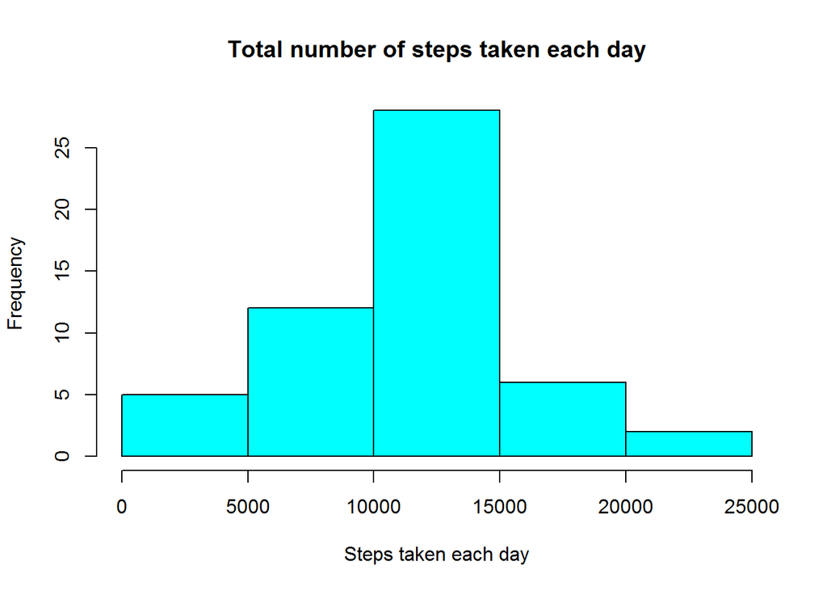

```r
hist(aggredata$steps,xlab = 'Steps taken each day', main = 'Total number of steps taken each day', col = 'cyan')
```

Mean of the total number of steps taken per day

```r
mean(aggredata$steps)
```

```
## [1] 10766.19
```

Median of the total number of steps taken per day

```r
median(aggredata$steps)
```

```
## [1] 10765
```

**2. What is the average daily activity pattern?**

Average number of steps, averaged across all days

```r
avgdata <- aggregate(steps~interval, data, mean)
```

Time series plot of the 5-minute interval (x-axis) and the average number of steps taken, averaged across all days (y-axis)

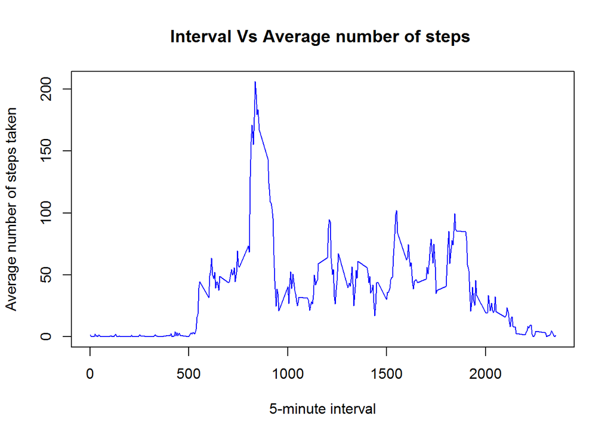

```r
plot(avgdata$interval,avgdata$steps, type = 'l', xlab = '5-minute interval', ylab = 'Average number of steps taken',main = 'Interval Vs Average number of steps ',col = 'blue')
```

Interval which has the maximum number of steps

```r
subset(avgdata,steps==max(avgdata$steps))
```

```
##     interval    steps
## 104      835 206.1698
```

**3. Imputing missing values**

The total number of missing values in the dataset

```r
sum(is.na(data))
```

```
## [1] 2304
```

Filling in all of the missing values in the dataset

Replacing NAâ€™s with mean for that 5-minute interval

```r
data_na <- data[is.na(data),]

for (i in 1:nrow(data_na)){
  steps_na <- avgdata[data_na$interval[i]==avgdata$interval,]
  data_na$steps[i] <- steps_na$steps

}

data_no_na <- data[!is.na(data),]
final_data <- rbind(data_no_na, data_na)
```

A new dataset final_data is created with the missing values filled in

The total number of steps taken each day after filling the missing data

```r
aggredata_no_na <- aggregate(steps~date, final_data, sum)
```

Histogram of the total number of steps taken each day after filling the missing data

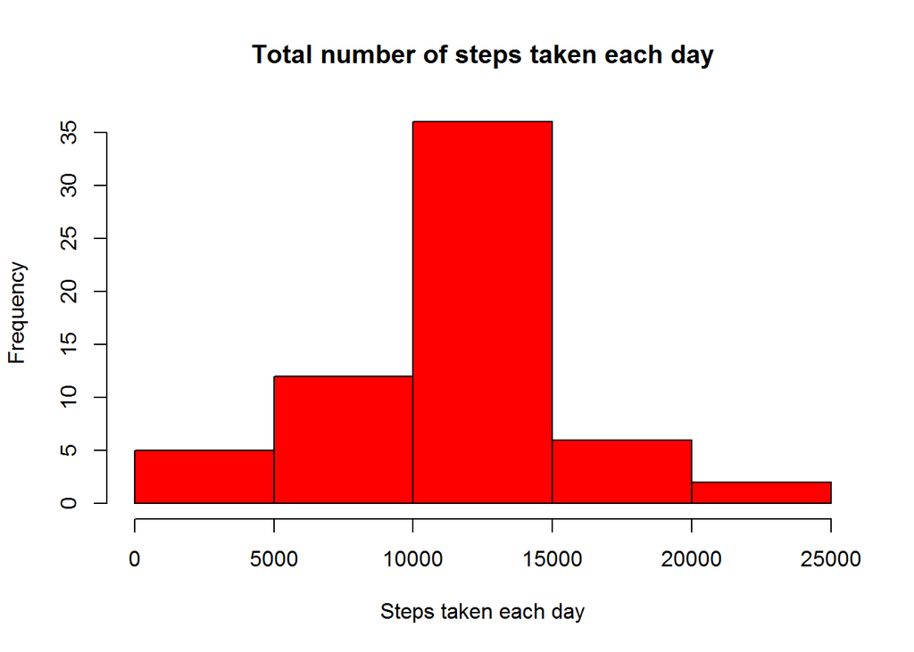

```r
hist(aggredata_no_na$steps,xlab = 'Steps taken each day', main = 'Total number of steps taken each day', col = 'red')
```

Mean of the total number of steps taken per day

```r
mean(aggredata_no_na$steps)
```

```
## [1] 10766.19
```

Median of the total number of steps taken per day

```r
median(aggredata_no_na$steps)
```

```
## [1] 10766.19
```

The mean and median does not change much even after filling the missing data

**4. Are there differences in activity patterns between weekdays and weekends?**

Creating a new variable indicating ‘weekday’ or ‘weekend’ for a given date

```r
final_data$weekday_weekend <- weekdays(as.Date(final_data$date))
final_data$weekday_weekend[final_data$weekday_weekend %in% c('Saturday','Sunday')] <- 'Weekend'
final_data$weekday_weekend[final_data$weekday_weekend != 'Weekend'] <- 'Weekday'

final_data$weekday_weekend <- as.factor(final_data$weekday_weekend)
```

Average number of steps, averaged across all days

```r
avgdata <- aggregate(steps~interval + weekday_weekend, final_data, mean)
```

Time series plot of the 5-minute interval (x-axis) and the average number of steps taken, averaged across all days (y-axis)

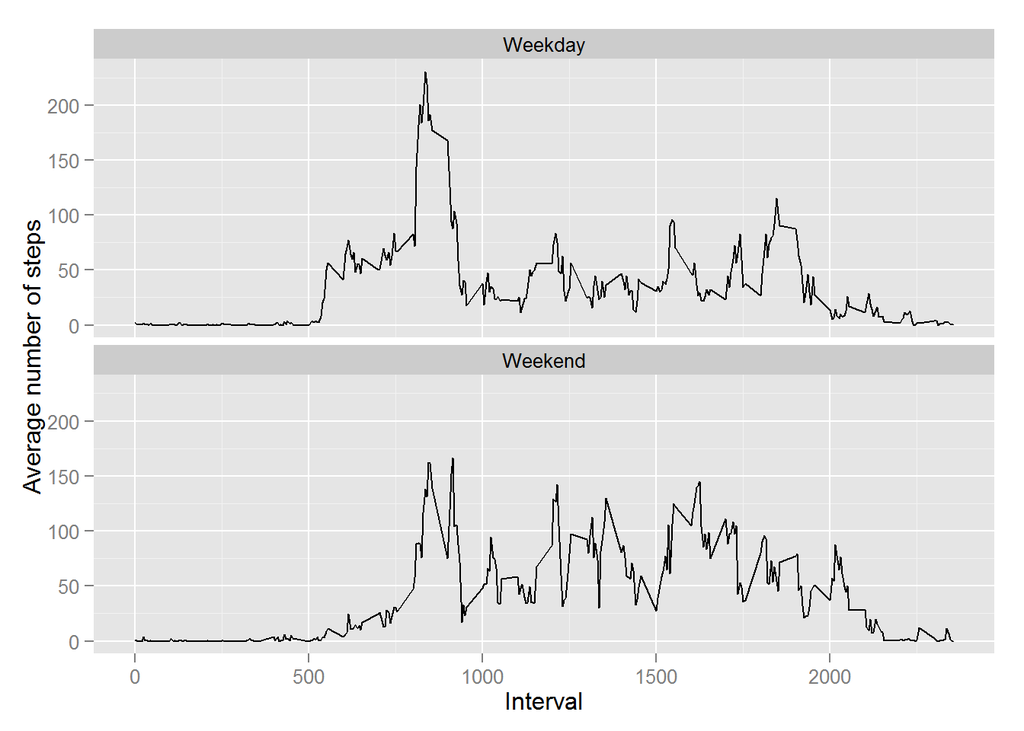

```r
library(ggplot2)
qplot(interval,steps,data = avgdata, geom = 'line',type = 'l', xlab = 'Interval', ylab = 'Average number of steps') + facet_wrap(~weekday_weekend, ncol = 1)
```